# Coursework 1

36071280

15/10/2021

## Leeds Accident data

Q1. Read the data into R, check the names of the variables match those in the table, and print the dimensions of the data frame.

```r
library(dplyr)
```

```r
library(ggplot2)

#Reading data fromCSV file
accidentsData = read.csv("accidents2014.csv")

#data.frame(accidentsData)

#Check column names -no need to print
#colnames(accidentsData)

#Get dimensions of the dataframe
dim(accidentsData)
```

```
## [1] 2533   16
```

Q2. Use select() to modify the data frame, dropping the following variables; Accident.Date, Time..24hr, Road.Surface, Lighting.Conditions, and Weather.Conditions and keeping the others.

```r
# Do it using column names and not strings
accidentsData_select = select(accidentsData, -c("Accident.Date","Road.Surface","Lighting.Conditions", "Weather.Conditions", "Time..24hr."))

#dim(accidentsData_select)
```

Q. Use filter() to modify the data frame, so that the accidents we are studying involve: a private car (vehicle category 9) and are not on a motorway (class of road category 1). Print the dimensions of your newly modified data frame.

```r
accidentsData_filtered = filter(accidentsData_select, accidentsData_select$Type.of.Vehicle == 9, accidentsData_select$X1st.Road.Class != 1)

dim(accidentsData_filtered)
```

```
## [1] 1515   11
```

Q3.The centre of Leeds has Easting-Northing coordinates, 429967, 434260. Add a variable to the accident data frame using mutate() to give the distance of the accident from the centre of Leeds in metres.

```r
#Defining leeds centre coordinates
x1 = 429967
y1 = 434260

#Defining function to calculate the distance from city centre
calc_distance <- function (x1, x2, y1, y2) {
  sqrt((x2-x1)^2 + (y2-y1)^2)
}

#Getting accidents data with distance column
accidentsData_withDistance = mutate(accidentsData_filtered,
                                    Distance.From.Centre = calc_distance(x1, accidentsData_filtered$Grid.Ref..Easting, y1, accidentsData_filtered$Grid.Ref..Northing) )
```

Using the modified data from question 2 and arrange() reorder the accidents in ascending order from the centre of Leeds and print out the bottom few rows from this data frame.

```r
accidentsData_orderedbyDistance = arrange(accidentsData_withDistance, accidentsData_withDistance$Distance.From.Centre)
tail(accidentsData_orderedbyDistance)
```

```
##      Reference.Number Grid.Ref..Easting Grid.Ref..Northing Number.of.Vehicles
## 1510          1BU1133            440547             448561                  3
## 1511          1BU1133            440547             448561                  3
## 1512          1BU1133            440547             448561                  3
## 1513          17V0436            439873             449526                  1
## 1514          13L0235            440411             449270                  1
## 1515          1AH0546            441101             449222                  2
##      Number.of.Casualties X1st.Road.Class Casualty.Class Casualty.Severity
## 1510                    3               4              1                 3
## 1511                    3               4              1                 3
## 1512                    3               4              2                 3
## 1513                    1               6              3                 3
## 1514                    1               4              3                 3
## 1515                    1               2              1                 3
##      Sex.of.Casualty Age.of.Casualty Type.of.Vehicle Distance.From.Centre
## 1510               1              91               9             17789.18
## 1511               1              65               9             17789.18
## 1512               2              63               9             17789.18
## 1513               1              42               9             18198.34
## 1514               1              14               9             18285.98
## 1515               1              56               9             18650.13
```

Q4. Continuing with the data modified in questions 2 and 3, using ggplot(), create a histogram of age of casualties. Modify the binwidth into groups of 10 years. Set the axis labels to be “Casualty age” and “No. of casualties”.

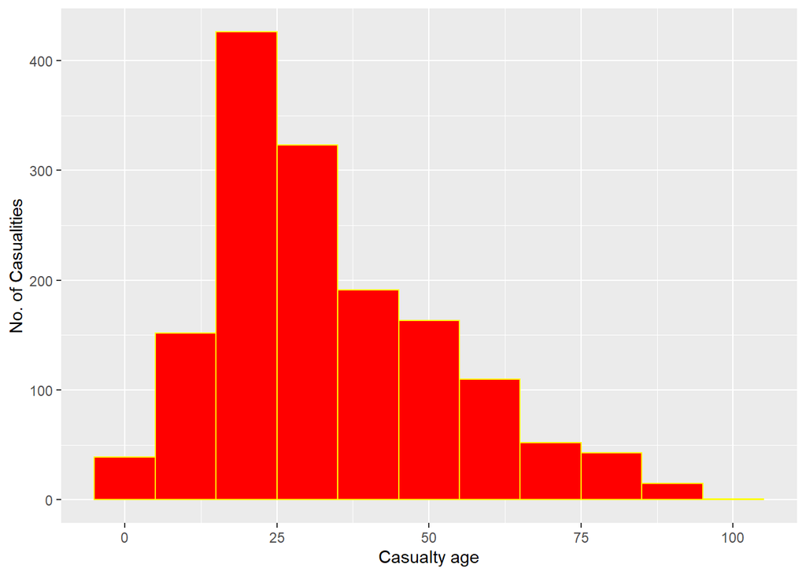

```r
# Creating histogram

ggplot(accidentsData_orderedbyDistance) + geom_histogram( aes(Age.of.Casualty),binwidth = 10, color="yellow", fill="red") + xlab("Casualty age") + ylab("No. of Casualities")
```